# Portfolio metrics and watershed characteristics

M. Snyder

Mar. 17, 2021

### All watersheds

Since, TotalLength_m is representing watershed size, the other variables are in terms of percent of the watershed area or length rather than area or length. Variables dropped are listed below.

```r
# subset metrics

landscape<-dplyr::select(landscape_raw, -HighCritHab_m, -HighCritHab_p,-MeanElev_m,
     -HighIP_m, -Watershed_sqkm, -HighIP_p, -Public_sqkm,
     -lake_area_km2, -est_area_km2, -wetland_area_km2,
      -LowGradient_m, -LogDriveLength_m, -Latitude)
```

Before doing the PCA, I scale the variables by subtracting the mean and dividing by the standard deviation rather than adding one and taking the log as Griffiths et al. 2014 did because negative numbers can’t be logged.

## PCA

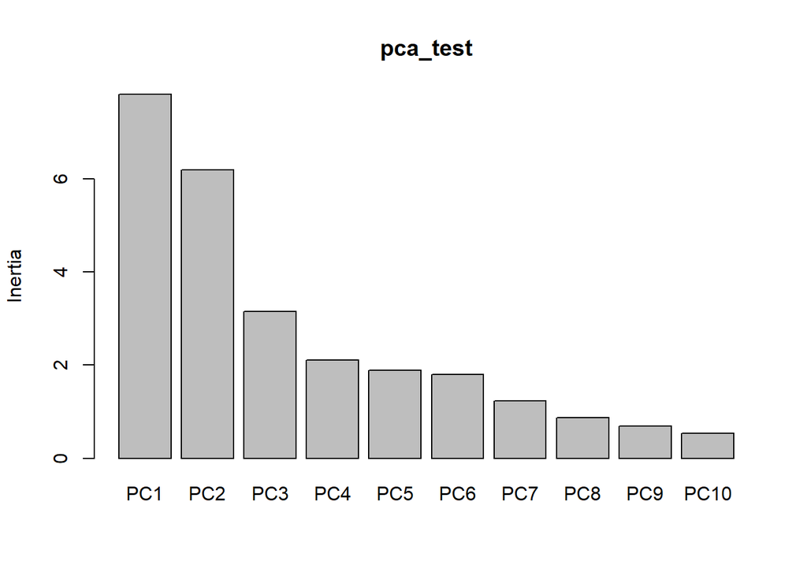

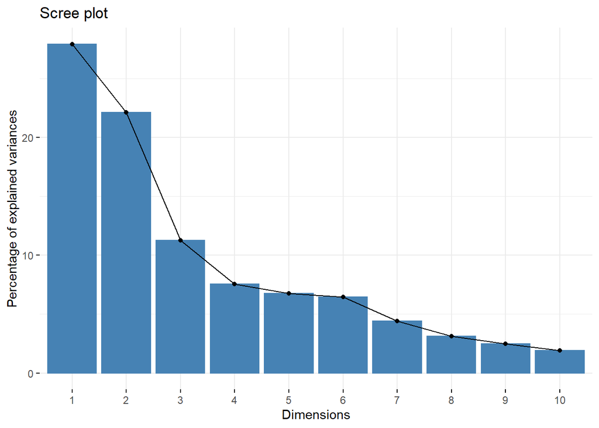

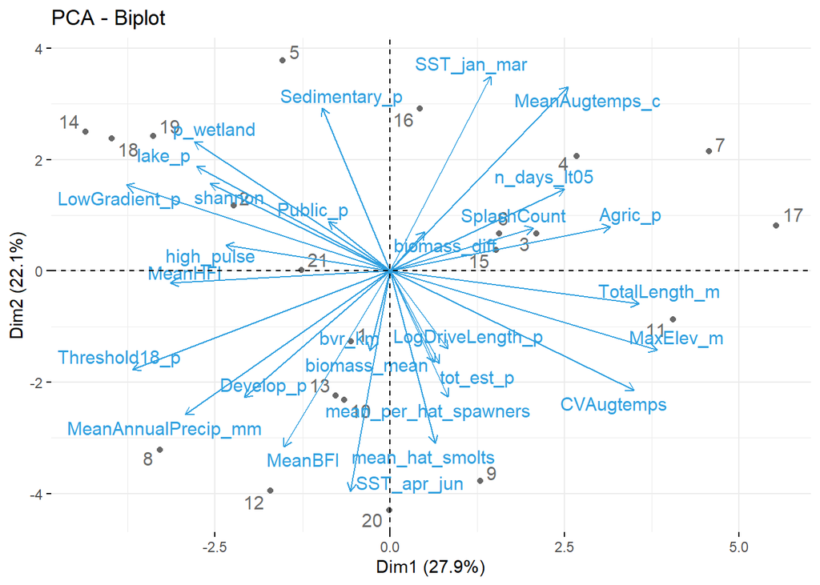

```
##          eigenvalue variance.percent cumulative.variance.percent
## Dim.1  7.815360e+00     2.791200e+01                    27.91200
## Dim.2  6.192558e+00     2.211628e+01                    50.02828
## Dim.3  3.156508e+00     1.127324e+01                    61.30152
## Dim.4  2.109502e+00     7.533936e+00                    68.83546
## Dim.5  1.890705e+00     6.752518e+00                    75.58798
## Dim.6  1.803739e+00     6.441926e+00                    82.02990
## Dim.7  1.234245e+00     4.408018e+00                    86.43792
## Dim.8  8.732059e-01     3.118593e+00                    89.55651
## Dim.9  6.916555e-01     2.470198e+00                    92.02671
## Dim.10 5.319300e-01     1.899750e+00                    93.92646
## Dim.11 4.068055e-01     1.452877e+00                    95.37934
## Dim.12 3.514739e-01     1.255264e+00                    96.63460
## Dim.13 2.311428e-01     8.255099e-01                    97.46011
## Dim.14 2.214166e-01     7.907735e-01                    98.25088
## Dim.15 1.375892e-01     4.913901e-01                    98.74227
## Dim.16 1.291158e-01     4.611278e-01                    99.20340
## Dim.17 9.655332e-02     3.448333e-01                    99.54824
## Dim.18 8.317902e-02     2.970679e-01                    99.84530
## Dim.19 2.697849e-02     9.635176e-02                    99.94166
## Dim.20 1.633644e-02     5.834444e-02                   100.00000
## Dim.21 3.710204e-32     1.325073e-31                   100.00000
```

```
## Principal Component Analysis Results for variables
##  ===================================================
##   Name       Description
## 1 "$coord"   "Coordinates for the variables"
## 2 "$cor"     "Correlations between variables and dimensions"
## 3 "$cos2"    "Cos2 for the variables"
## 4 "$contrib" "contributions of the variables"
```

## Biplot of PCA.

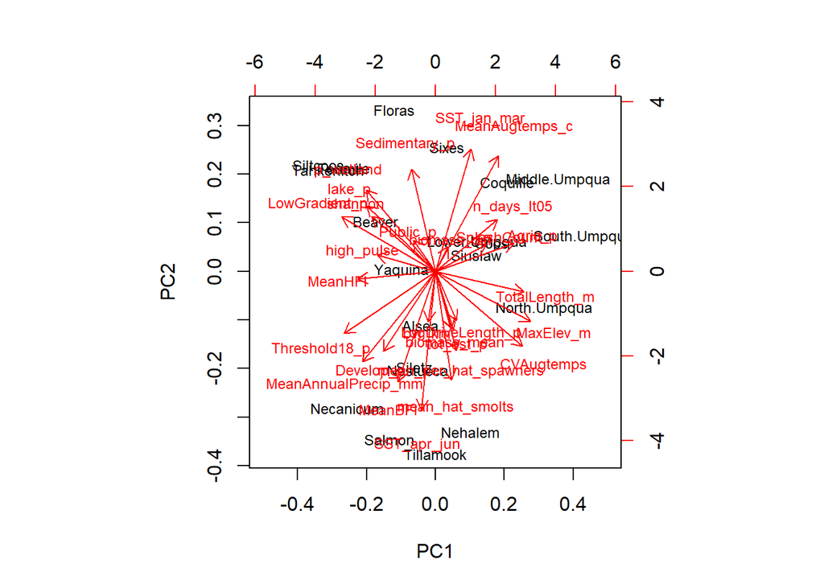

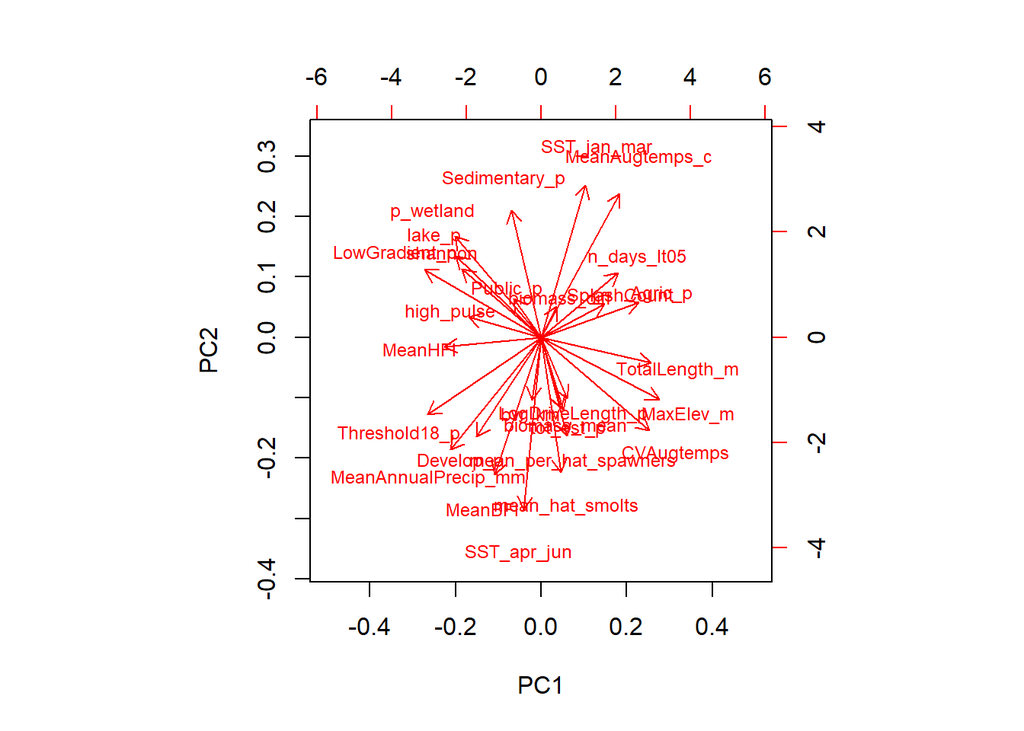

## biplot loadings >0.2 PC2

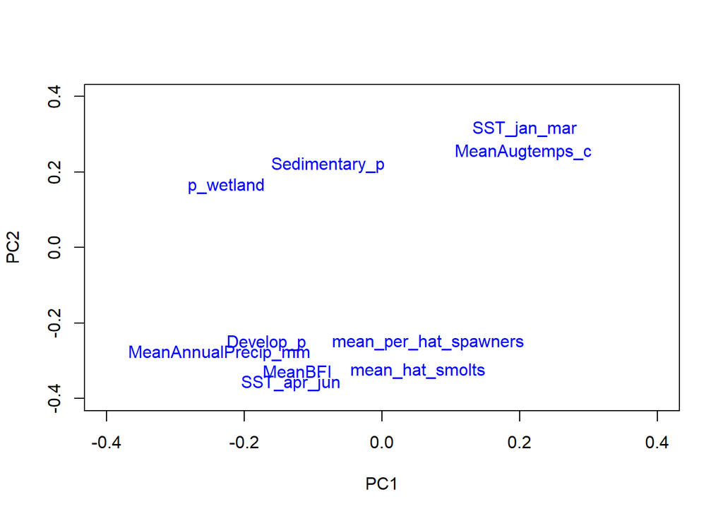

## Biplot of with subset of variables that have > 0.2 loadings weight on PC1 or PC2.

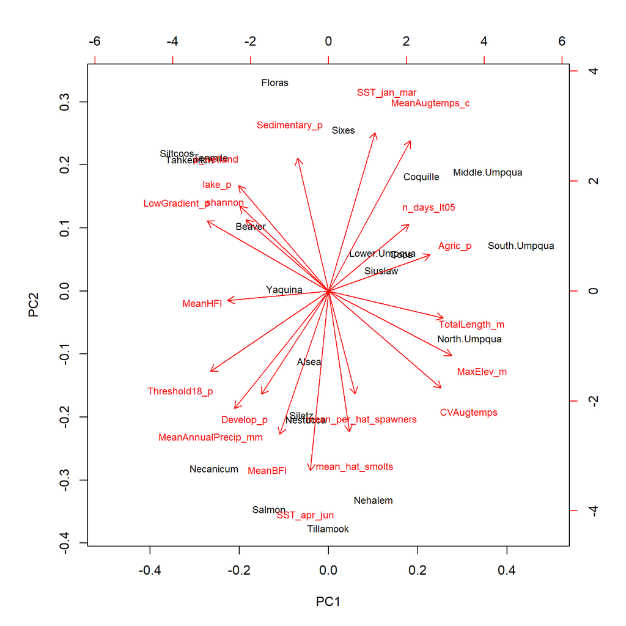

## Biplot of with subset of variables that have > 0.2 loadings weight on PC2 or PC3.

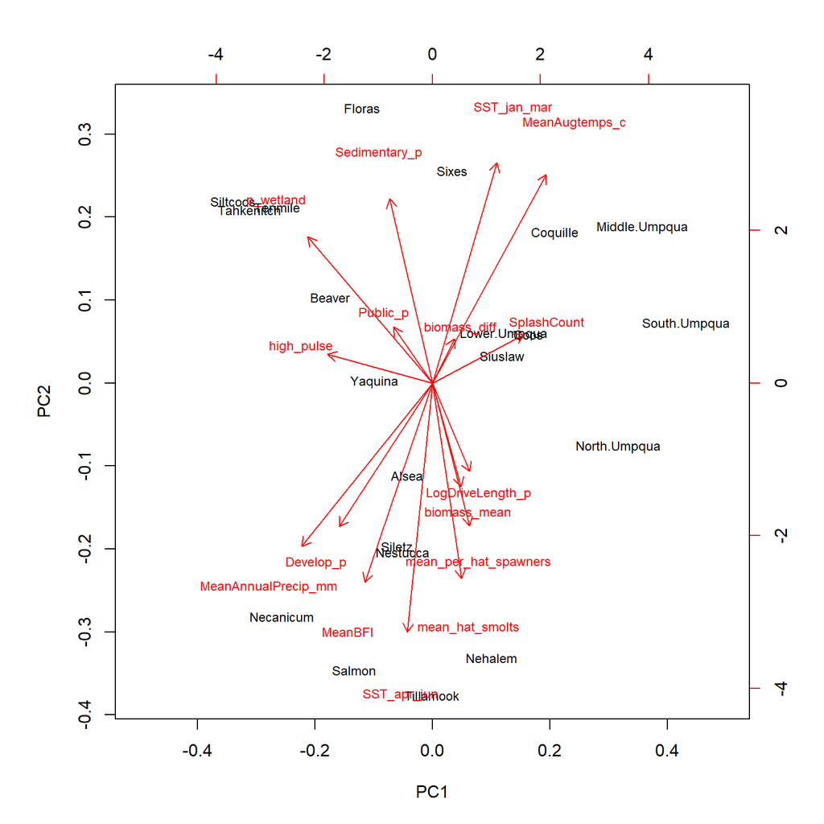

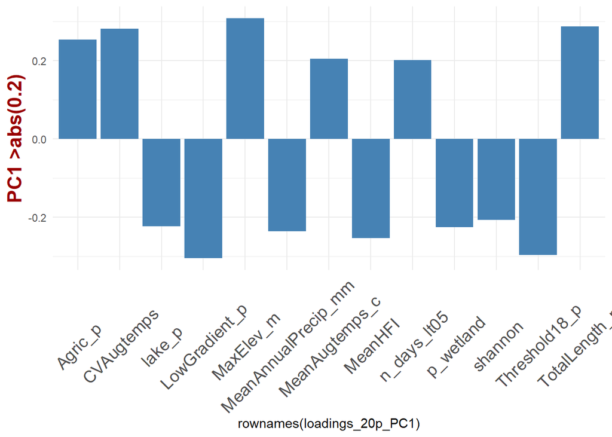

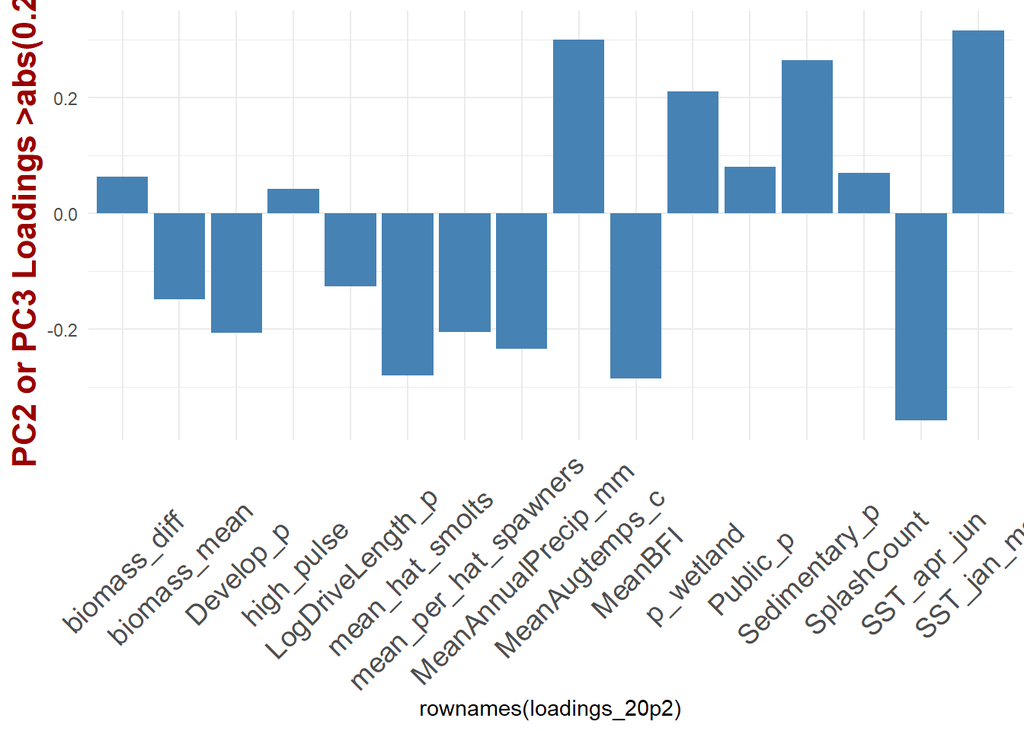

## Barplot including variables with loadings on PC2 > 0.2

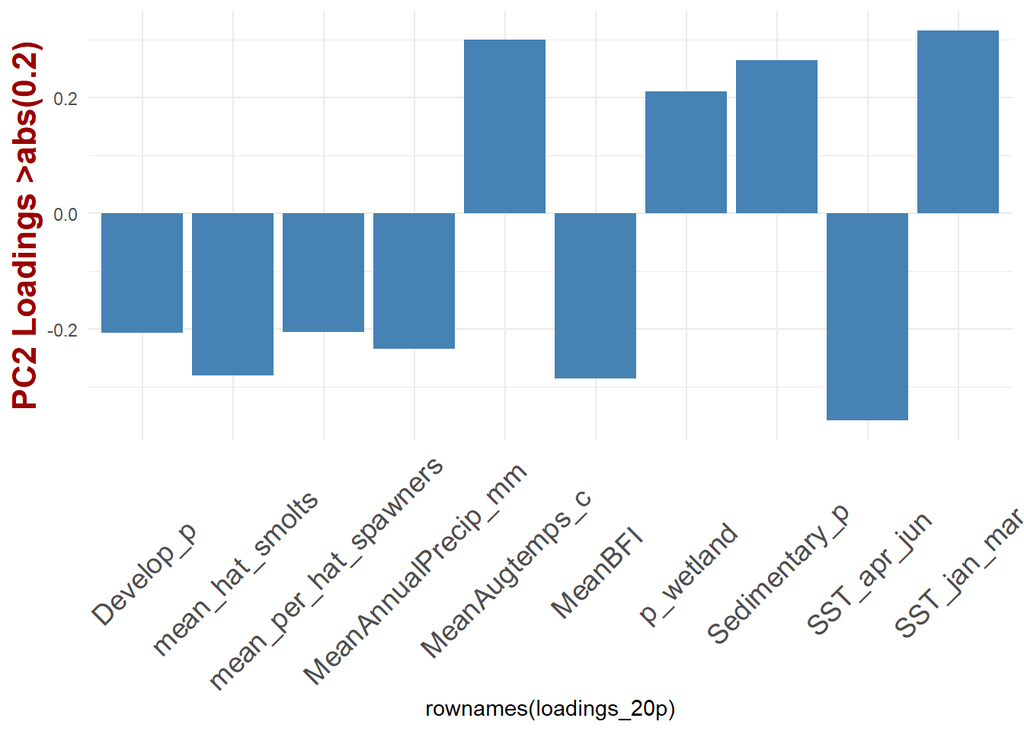

## Barplot including variables with loadings on PC3 > 0.2

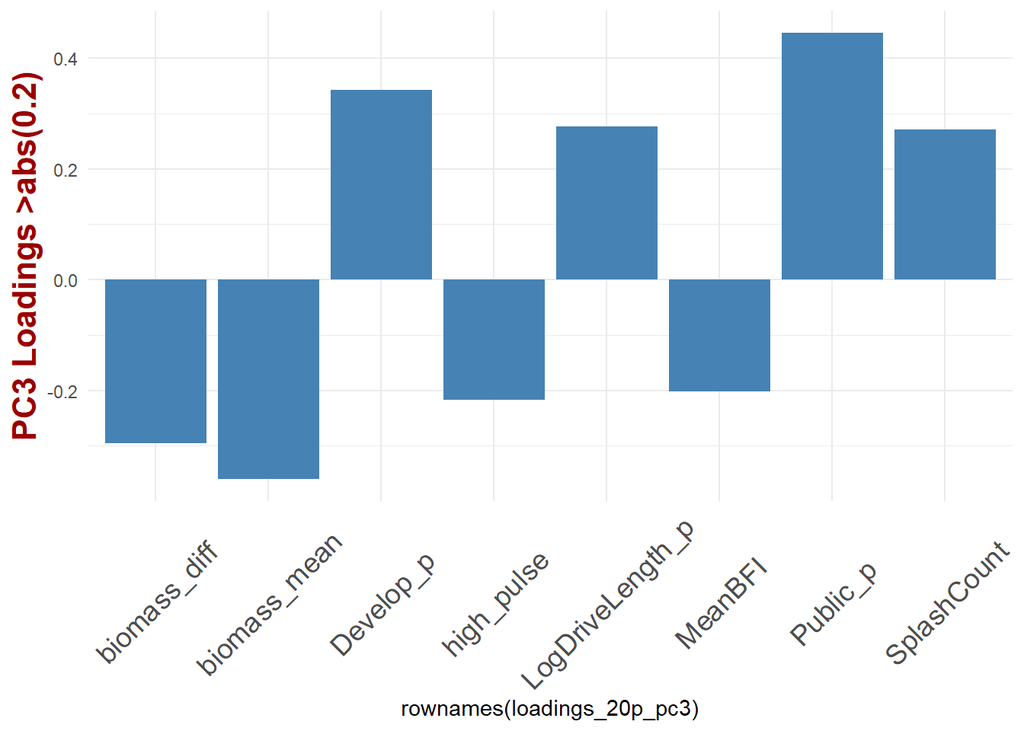

Convert principal components to scores for each watershed and join tables with CV, DD,with watershed characteristics, and PCA scores.

### Test for correlations again between significant PCA components with CV

| Principal component | CVcurrent |
| --- | --- |
| PC1 | -0.103896103896104 |
| PC2 | 0.537662337662338 |
| PC3 | 0.0558441558441558 |

### Test for correlations again between significant PCA components with DD

| Principal component | DD |
| --- | --- |
| PC1 | -0.533766233766234 |
| PC2 | 0.527272727272727 |
| PC3 | -0.261038961038961 |

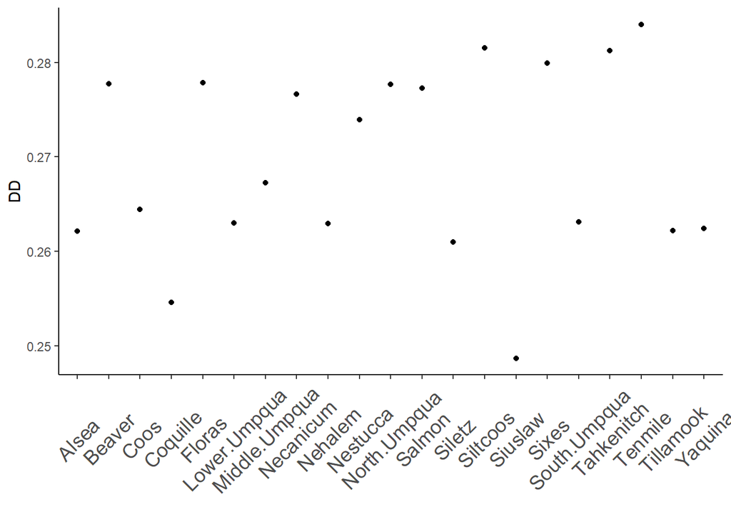

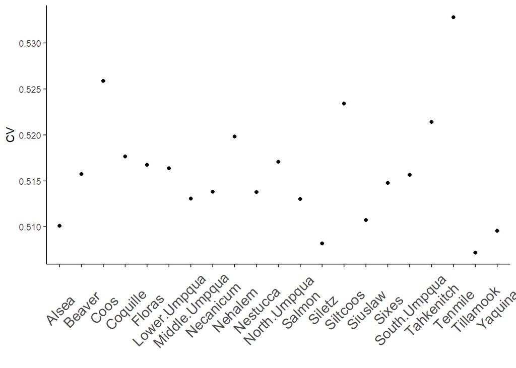